# Introduction to run charts in R

a standalone training session

Author

Brendan Clarke, NHS Education for Scotland, brendan.clarke2@nhs.scot

Published

April 17, 2023

**Run charts intro**

= a way of plotting time series data when you’re interested in variation

Good starter guide from [NHS England](https://www.england.nhs.uk/wp-content/uploads/2021/12/qsir-run-charts.pdf)

### Terminology

- common cause = controlled variation. Confusing name for chance!
- special cause = real change over time

### Elements

- plot points against time
- add median line of some/all data points
- look at how points lie relative to the median

**Simple run chart in ggplot()**

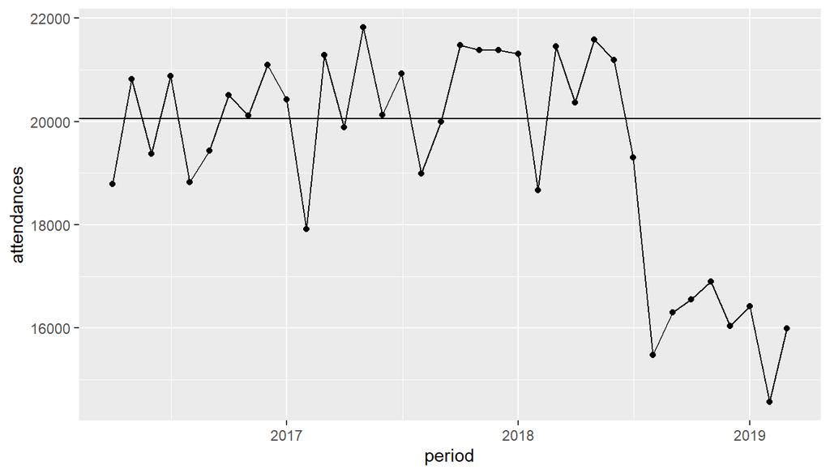

```r
ae_attendances %>%
  filter(org_code == "RF4" & type == "1") %>%
  ggplot(aes(x=period, y=attendances)) +
  geom_point() +
  geom_line() +
  geom_hline(aes(yintercept=median(attendances)))
```

We can turn that into a function fairly easily:

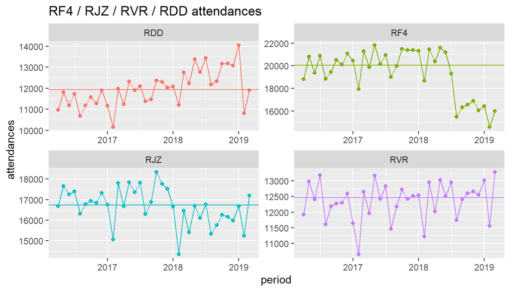

```r
run_chart <- function(org, cat) {

  ae_attendances %>%
    filter(org_code %in% {{org}} & type == "1") %>%
    group_by(org_code) %>%
    mutate(median = median({{cat}})) %>%
    ggplot(aes(x=period, y={{cat}}, color=org_code)) +
    geom_point() +
    geom_line() +
    geom_hline(aes(yintercept=median, color=org_code)) +
    ggtitle(glue("{paste(org, collapse=' / ')} {deparse(substitute(cat))}")) +
    theme(legend.position="none") +
    facet_wrap(~ org_code, scales="free")
}

run_chart(c("RF4", "RJZ", "RVR", "RDD"), attendances)
```

**Interpreting run charts**

Lots to say, clearly, but four important features:

### Shift

7 or more points on one side of the median

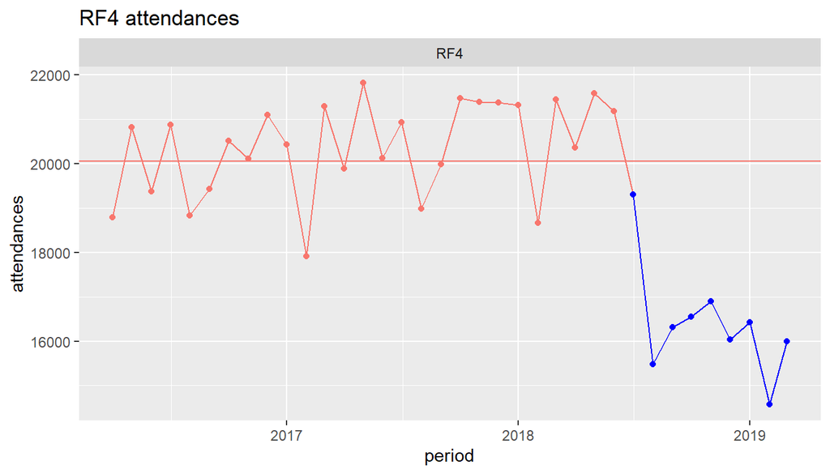

```r
run_chart("RF4", attendances) +
  geom_point(data = . %>% filter(period >= dmy("01/07/2018")), color="blue" ) +
  geom_line(data = . %>% filter(period >= dmy("01/07/2018")), color="blue")
```

### Trend

7 or more points going in the same direction

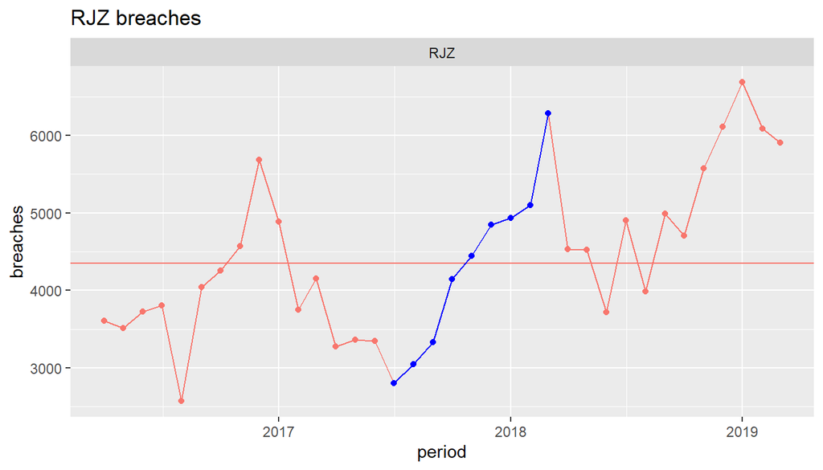

```r
run_chart("RJZ", breaches) +
  geom_point(data = . %>% filter(period %within% interval(dmy("01/07/2017"), dmy("01/03/2018"))), color="blue") +
  geom_line(data = . %>% filter(period %within% interval(dmy("01/07/2017"), dmy("01/03/2018"))), color="blue" )
```

### Run

The number of times the line crosses the median. Too few runs indicates that special cause variation might be at play. Runs = count of crossing medians + 1:

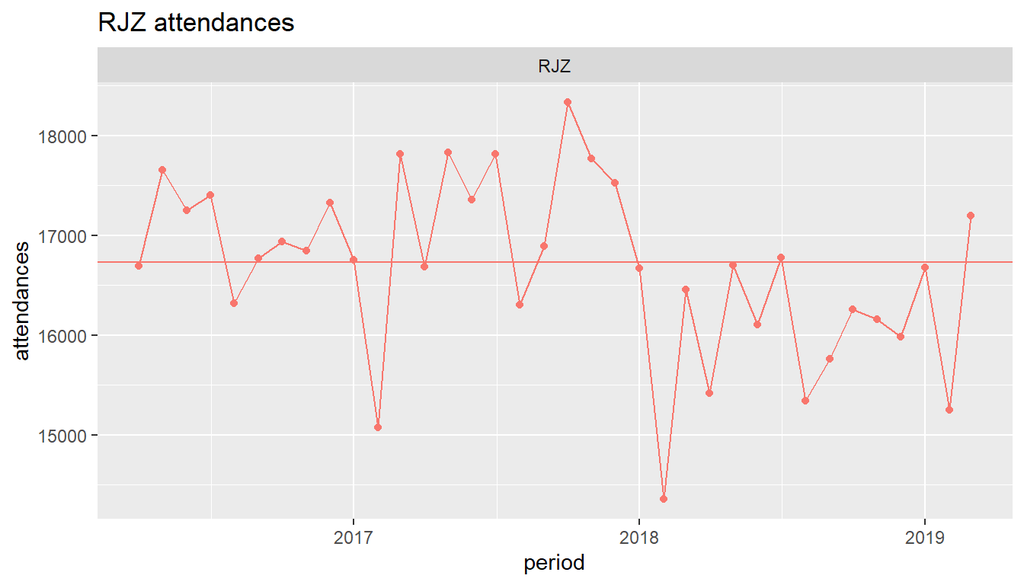

```r
run_chart("RJZ", attendances) # 14 runs
```

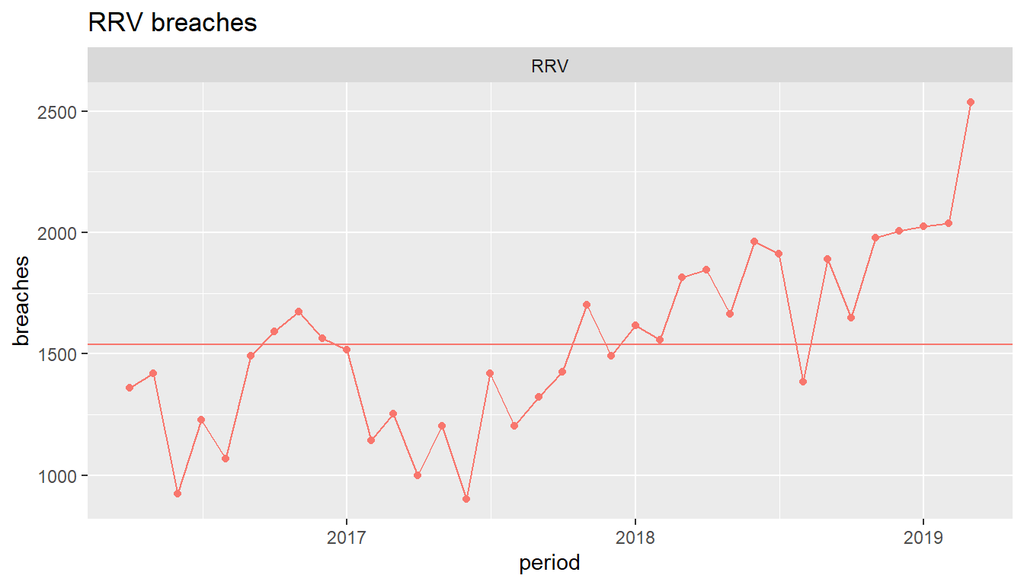

```r
run_chart("RRV", breaches) # 7 runs
```

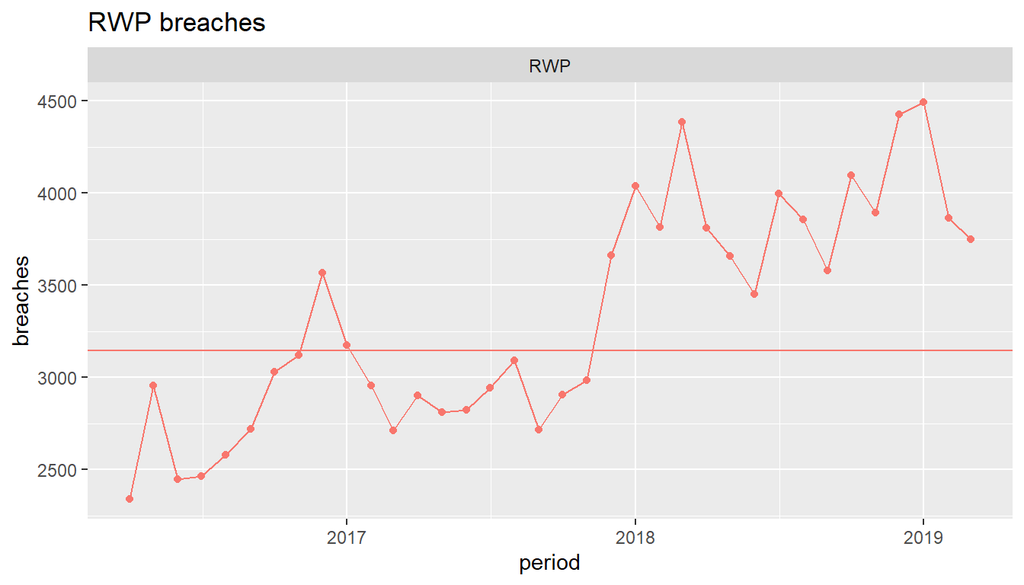

```r
run_chart("RWP", breaches) # 3 runs
```

### Astronomical point

A by-inspection outlier:

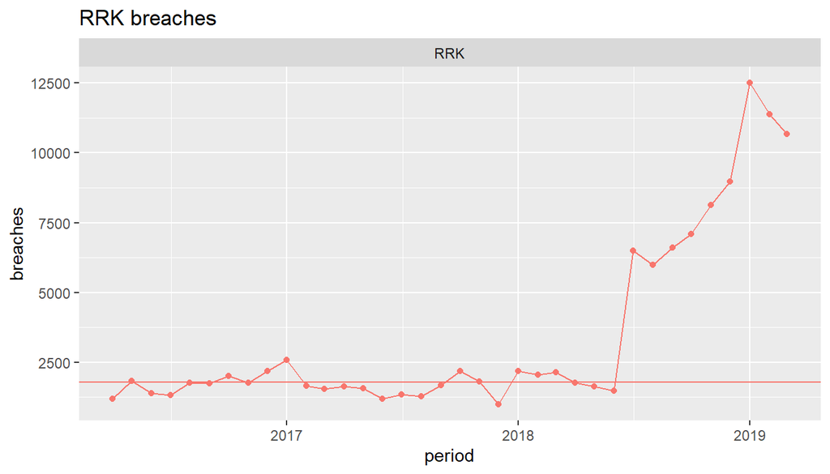

```r
run_chart("RRK", breaches) # ?astronomical point
```

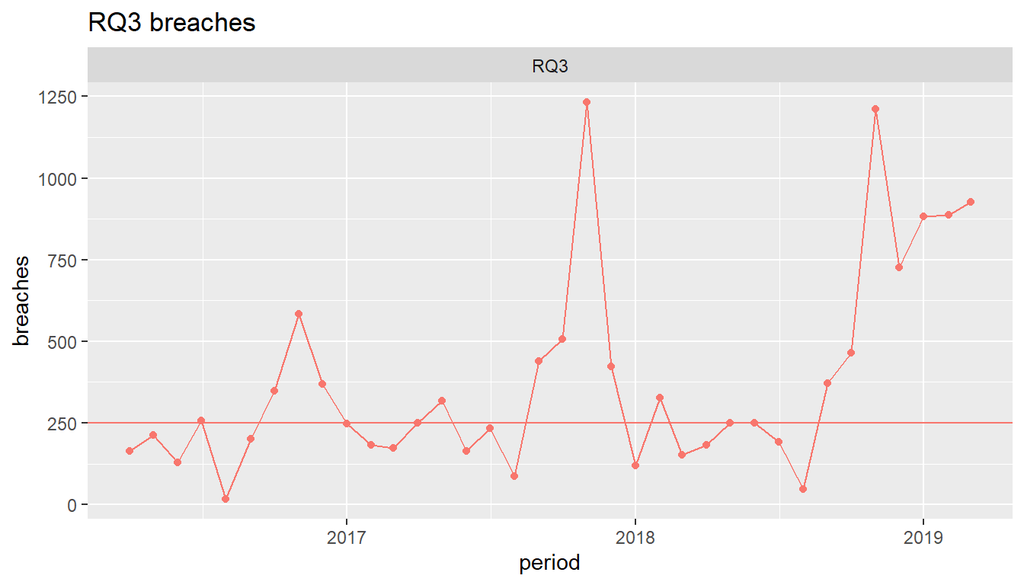

```r
run_chart("RQ3", breaches) # ?astronomical point
```

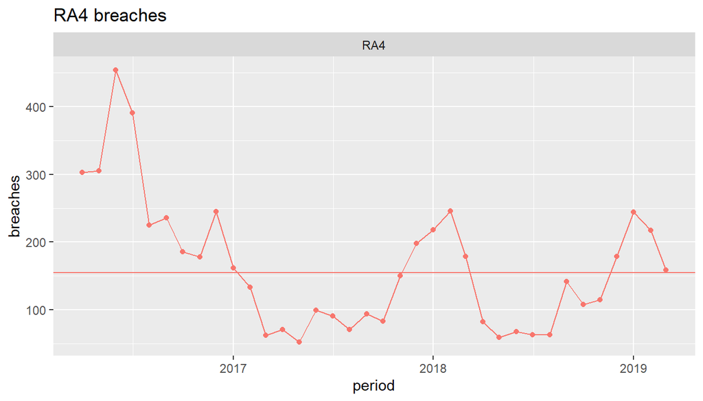

```r
run_chart("RA4", breaches) # probably not an astronomical point
```

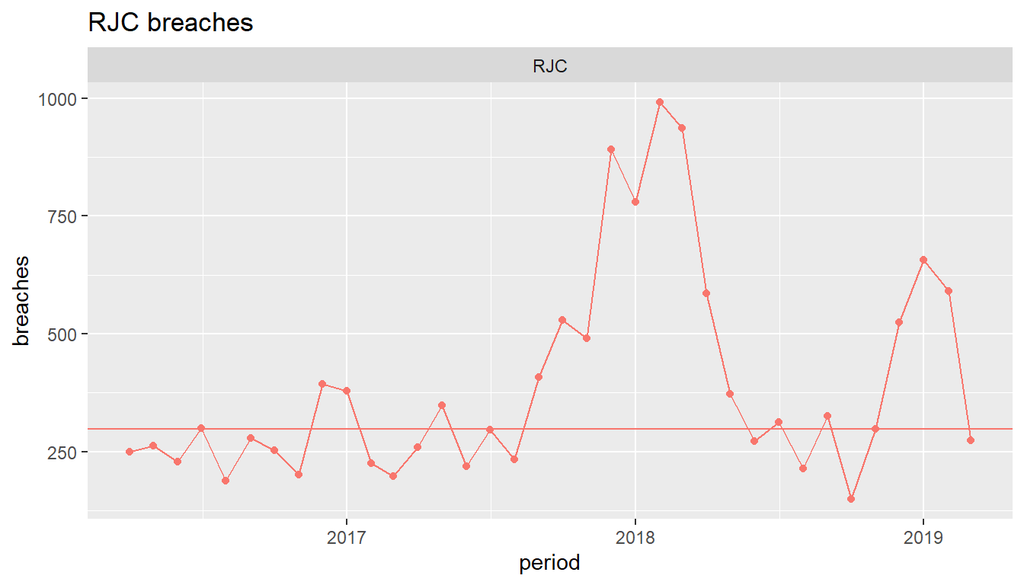

```r
run_chart("RJC", breaches) # probably not an astronomical point
```

**NHSRplotthedots**

This section is intended as a demonstration of the NHSRplotthedots package, which provides a ggplot-like approach to building XmR charts that follow the [NHS Plot The Dots](https://www.england.nhs.uk/wp-content/uploads/2019/12/making-data-count-getting-started-2019.pdf) logic.

More theory: statistical process control

Control limits = measure of variation in the data centre line = usually mean (sometimes median) +- target lines 15-20 data points minimum

XmR chart = one type of SPC chart

Slightly different interpretation [NHS England again](https://www.england.nhs.uk/wp-content/uploads/2022/02/qsir-statistical-process-control.pdf)

special purpose variation if and only if one of the following four are found - point outwith control limits - run of >=7 on one side of mean / drift of >=7 in one direction - cyclic or trend pattern - many more or less that 2/3 of points in middle 1/3 of control region

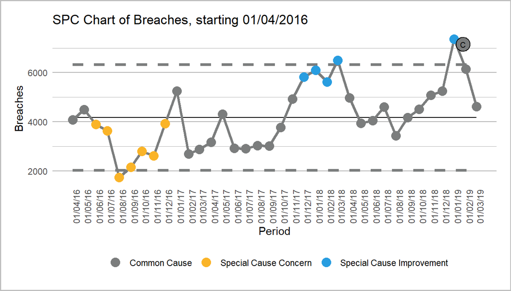

```r
ae_attendances %>%
  filter(type == "1" & org_code=="RF4") %>%
  ptd_spc(value_field = "breaches", date_field = period, improvement_direction = "increase")
```

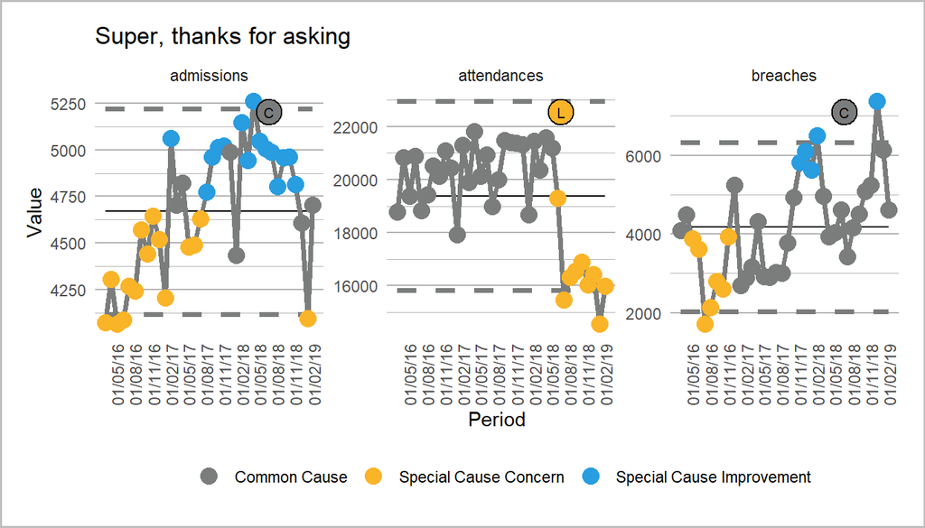

```r
ae_attendances %>%
  filter(type == "1" & org_code=="RF4") %>%
  pivot_longer(c(admissions, attendances, breaches)) %>%
  ptd_spc(value_field = "value", facet_field = "name", date_field = period, improvement_direction = "increase") %>%
  plot(fixed_y_axis_multiple = FALSE, x_axis_breaks = "3 months", main_title="Super, thanks for asking")
```

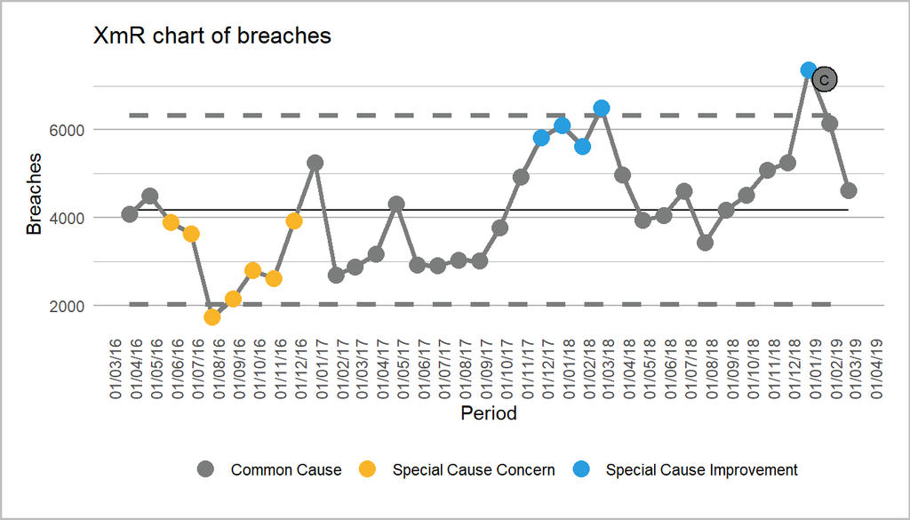

```r
ae_attendances %>%
  filter(type == "1" & org_code=="RF4") %>%
  ptd_spc(value_field = "breaches", date_field = period, improvement_direction = "increase") %>%
  plot(x_axis_breaks = "1 month", main_title="XmR chart of breaches", theme =)
```

It’s also worth looking at the excellent [runcharter package](https://johnmackintosh.github.io/runcharter/) if you need to produce series of run charts as this package allows more control over faceted charts).

**Runcharter**

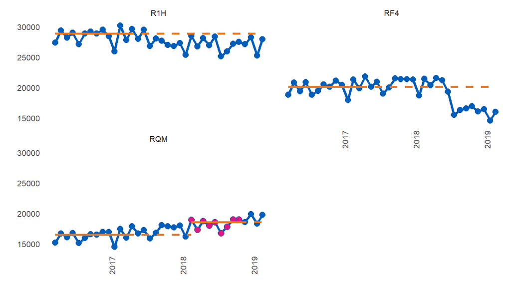

```r
set <- ae_attendances %>%
  filter(org_code %in% c("RF4", "R1H", "RYX", "RQM") & type == "1") %>%
  select(period, org_code, attendances)

thing <-
  runcharter(
  set,
  med_rows = 13,
  runlength = 9,
  direction = "above",
  datecol = period,
  grpvar = org_code,
  yval = attendances,
  facet_cols = 2)

thing$runchart
```

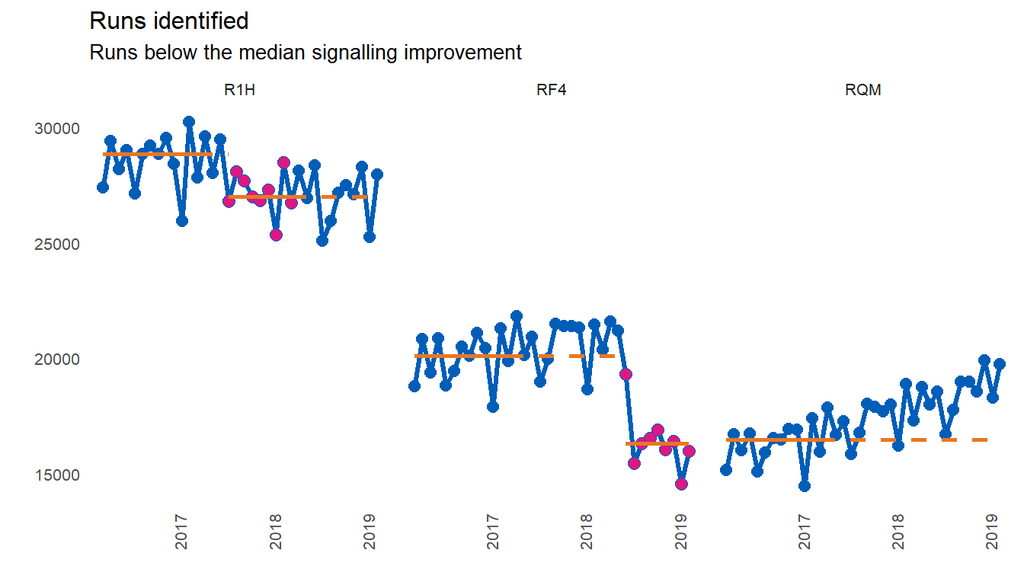

```r
runcharter(set,
            runlength = 9,
           direction = "below",
           datecol = period,
           grpvar = org_code,
           yval = attendances,
          chart_title = "Runs identified",
          chart_subtitle = "Runs below the median signalling improvement")$runchart
```